# model_refinement_experiments

In this notebook, different model refinement methods are applied incrementally to generate multiple models, each with a change to the dataset used for the baseline model. The new models are then compared to the baseline model to show how each change affects model's performance and validity.

**Models for comparison:**

- Baseline model: Built in my_project.ipynb notebook
- Model 1: Apply transformation to dependent variable to fix skewness or non-linearity
- Model 2: Add interaction term
- Model 3 (final): Apply both dependent variable transformation and interaction term, but now use robust standard errors (HC3)

**Baseline model metrics:**

- Test set R-squared: 0.7961
- MSE: 4.3551
- Train set R-squared: 0.763
- Train set adjusted R-squared: 0.761

**Prerequisite:** The new models are trained and tested using the transformed dataset (`transformed_data.csv`) generated in `main_analysis.ipynb`.

**Contents:**  
Model 1 with Transformed Dependent Variable  
Model 2 with Interaction Term  
Model 3 with Transformed Dependent Variable, Interaction Term and Robust Standard Error  
Conclusion

```python
import pandas as pd
import seaborn as sns
import matplotlib.pyplot as plt
import numpy as np
import statsmodels.api as sm
import scipy.stats as stats
from sklearn.preprocessing import MinMaxScaler
from sklearn.model_selection import train_test_split
from sklearn.metrics import mean_squared_error, r2_score
```

```python
# Load the transformed dataset
df = pd.read_csv('../data/transformed_data.csv')
df.head()
```

|  | poverty_rate | health_insurance | unemployment_rate | bachelor_holders | public_assistance | log_median_income | log_public_transit | sqrt_median_house_value |
| --- | --- | --- | --- | --- | --- | --- | --- | --- |
| 0 | 9.7 | 93.2 | 2.0 | 20.64 | 0.58 | 11.197050 | 0.000000 | 554.075807 |
| 1 | 21.3 | 91.1 | 5.4 | 11.84 | 1.65 | 10.835258 | 0.000000 | 401.123422 |
| 2 | 18.3 | 89.4 | 3.8 | 10.75 | 1.34 | 10.983987 | 0.262364 | 451.663592 |
| 3 | 24.7 | 86.1 | 3.8 | 9.33 | 2.66 | 10.680723 | 0.000000 | 395.979797 |
| 4 | 12.9 | 92.4 | 2.7 | 17.73 | 0.17 | 11.191038 | 0.000000 | 479.478884 |

## Model 1 with Transformed Dependent Variable

**Justification:** The baseline model uses the raw poverty rate as the dependent variable. That may distort relationships, especially when poverty is skewed. Applying a square root transformation to the response variable helps stabilize variance and reduce skewness.

```python
df1 = df.copy()
```

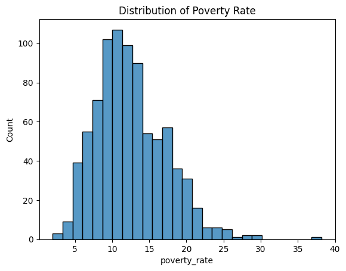

```python
# Observe the distribution of poverty rate
sns.histplot(df1['poverty_rate'])
plt.title('Distribution of Poverty Rate')
plt.show()
```

```python
# Apply transformation
df1['sqrt_poverty_rate'] = np.sqrt(df1['poverty_rate'])
df1.drop(columns='poverty_rate', inplace=True)
```

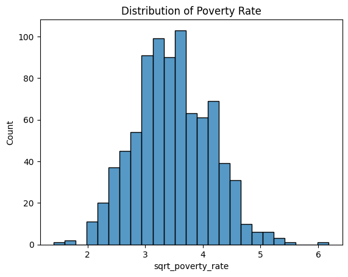

```python
# Observe the distribution of poverty rate after transformation
sns.histplot(df1['sqrt_poverty_rate'])
plt.title('Distribution of Poverty Rate')
plt.show()
```

**Build the model 1:**

```python
predictors = df1.drop(columns='sqrt_poverty_rate')
# Apply scaling
scaler = MinMaxScaler()
scaled_predictors = scaler.fit_transform(predictors)
scaled_predictors = pd.DataFrame(scaled_predictors, columns=predictors.columns)
scaled_predictors.head()
```

|  | health_insurance | unemployment_rate | bachelor_holders | public_assistance | log_median_income | log_public_transit | sqrt_median_house_value |
| --- | --- | --- | --- | --- | --- | --- | --- |
| 0 | 0.809353 | 0.131579 | 0.431118 | 0.054976 | 0.407074 | 0.000000 | 0.324462 |
| 1 | 0.733813 | 0.429825 | 0.165257 | 0.156398 | 0.160677 | 0.000000 | 0.171533 |
| 2 | 0.672662 | 0.289474 | 0.132326 | 0.127014 | 0.261968 | 0.065926 | 0.222065 |
| 3 | 0.553957 | 0.289474 | 0.089426 | 0.252133 | 0.055432 | 0.000000 | 0.166390 |
| 4 | 0.780576 | 0.192982 | 0.343202 | 0.016114 | 0.402980 | 0.000000 | 0.249876 |

```python
# Add intercept to scaled explanatory data and specify the dependent variable
X = sm.add_constant(scaled_predictors)
y = df1['sqrt_poverty_rate']

# Split data into training and testing sets
X_train, X_test, y_train, y_test = train_test_split(X, y, test_size=0.2, random_state=42)

# Fit the model
ols = sm.OLS(y_train, X_train)
model1 = ols.fit()
```

**Validate the model 1:**

```python
# Make predictions on the test set
y_pred = model1.predict(X_test)

# Calculate R-squared and MSE
r2 = r2_score(y_test, y_pred)
mse = mean_squared_error(y_test, y_pred)
print(f'R-squared: {r2}')
print(f'Mean Squared Error: {mse}')
```

```
R-squared: 0.8202081929882445
Mean Squared Error: 0.07654129696425717
```

```python
# View model summary
print(model1.summary())
```

```
                            OLS Regression Results
==============================================================================
Dep. Variable:      sqrt_poverty_rate   R-squared:                       0.786
Model:                            OLS   Adj. R-squared:                  0.784
Method:                 Least Squares   F-statistic:                     350.2
Date:                Tue, 22 Apr 2025   Prob (F-statistic):          2.00e-218
Time:                        23:16:09   Log-Likelihood:                -154.94
No. Observations:                 674   AIC:                             325.9
Df Residuals:                     666   BIC:                             362.0
Df Model:                           7
Covariance Type:            nonrobust
===========================================================================================
                              coef    std err          t      P>|t|      [0.025      0.975]
-------------------------------------------------------------------------------------------
const                       4.6822      0.085     54.813      0.000       4.515       4.850
health_insurance           -0.3494      0.095     -3.693      0.000      -0.535      -0.164
unemployment_rate           0.8497      0.102      8.292      0.000       0.649       1.051
bachelor_holders            0.0998      0.114      0.876      0.381      -0.124       0.323
public_assistance           0.0505      0.112      0.452      0.652      -0.169       0.270
log_median_income          -3.8575      0.141    -27.314      0.000      -4.135      -3.580
log_public_transit          0.7950      0.093      8.545      0.000       0.612       0.978
sqrt_median_house_value     0.8055      0.161      5.016      0.000       0.490       1.121
==============================================================================
Omnibus:                       13.463   Durbin-Watson:                   1.817
Prob(Omnibus):                  0.001   Jarque-Bera (JB):               24.153
Skew:                          -0.050   Prob(JB):                     5.69e-06
Kurtosis:                       3.922   Cond. No.                         25.0
==============================================================================

Notes:
[1] Standard Errors assume that the covariance matrix of the errors is correctly specified.
```

**Key findings:**

- Both R-squared on test set and MSE are better than those of the baseline model.
- R-squared (0.786) and adjusted R-squared (0.784) show improvement from baseline.
- Coefficients suggest the same general direction with smaller magnitude as in the baseline model.
- `bachelor_holders` and `public_assistance` remained statistically insignificant.

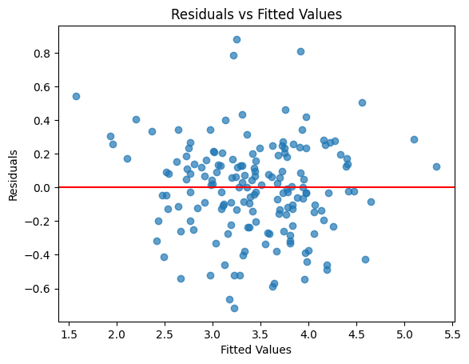

```python
# Residuals vs fitted values plot
residuals = y_test - y_pred
plt.scatter(y_pred, residuals, alpha=0.7)
plt.axhline(0, color='red')
plt.xlabel('Fitted Values')
plt.ylabel('Residuals')
plt.title('Residuals vs Fitted Values')
plt.show()
```

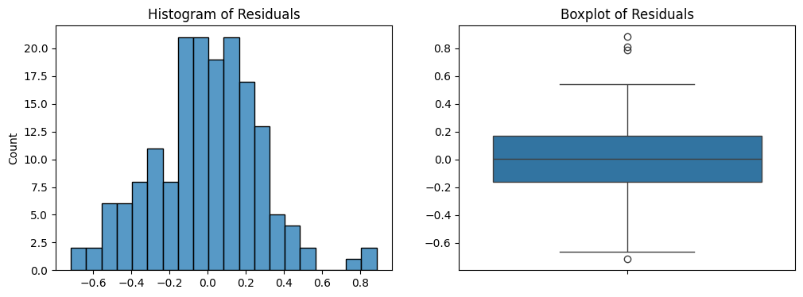

```python
fig, axes = plt.subplots(1, 2, figsize=(12,4))
# Histogram of residuals
sns.histplot(residuals, bins=20, edgecolor='black', ax=axes[0])
axes[0].set_title('Histogram of Residuals')
# Boxplot of residuals
sns.boxplot(residuals, ax=axes[1])
axes[1].set_title('Boxplot of Residuals')

plt.show()
```

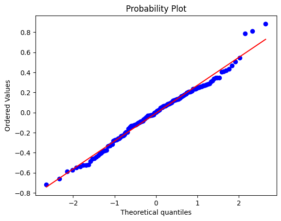

```python
# Q-Q plot to check for normality of residuals
stats.probplot(residuals, dist='norm', plot=plt)
plt.show()
```

**Key findings:**

- Some residual non-linearity and mild heteroscedasticity still present in diagnostic plots.
- The residuals are evenly distributed.

## Model 2 with Interaction Term

**Justification:** Socioeconomic variables may not act independently in influencing poverty. Adding interaction terms allows the model to capture more complex, real-world relationships between predictors. If significant, it can increase both predictive accuracy and interpretability.

An interaction term can be identified by asking this question: Do any predictors influence each other’s effects on the dependent variable? In the baseline model, I'm assuming that household income has the same effect everywhere, regardless of house values. But what if counties with medium to high income have housing affordability issues? The impact of household income on poverty may differ based on local housing cost.

```python
df2 = df.copy()
```

```python
# Bin sqrt_median_house_value into categories
bins = [0, 600, 1300]
labels = ['Low', 'High']
house_value_bin = pd.cut(df2['sqrt_median_house_value'], bins=bins, labels=labels)
```

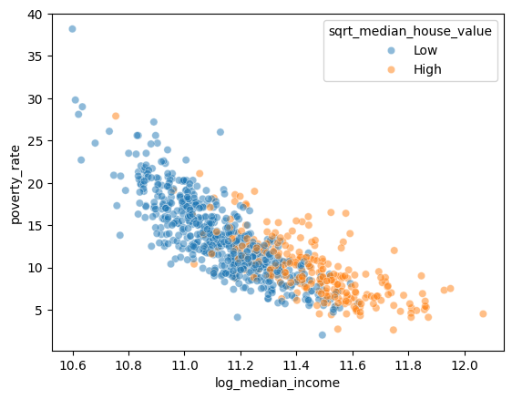

```python
sns.scatterplot(x='log_median_income', y='poverty_rate', hue=house_value_bin, data=df2, alpha=0.5)
plt.show()
```

**Key findings:**

- There's a clear negative relationship between `log_median_income` and `poverty_rate`.
- Higher housing cost also associates with higher income
- At the same income level, counties with higher `sqrt_median_house_value` (orange points) seem to have higher poverty rates than counties with lower house values (blue points).
- The drop in poverty rate with increasing income appears steeper for counties with lower house value than ones with higher house value. This means that the effect of income on poverty varies depending on house values.

```python
df2['income_x_house_value'] = (df2['log_median_income'] * df2['sqrt_median_house_value'])
```

**Build model 2:**

```python
predictors = df2.drop(columns='poverty_rate')
# Apply scaling
scaler = MinMaxScaler()
scaled_predictors = scaler.fit_transform(predictors)
scaled_predictors = pd.DataFrame(scaled_predictors, columns=predictors.columns)
scaled_predictors.head()
```

|  | health_insurance | unemployment_rate | bachelor_holders | public_assistance | log_median_income | log_public_transit | sqrt_median_house_value | income_x_house_value |
| --- | --- | --- | --- | --- | --- | --- | --- | --- |
| 0 | 0.809353 | 0.131579 | 0.431118 | 0.054976 | 0.407074 | 0.000000 | 0.324462 | 0.310475 |
| 1 | 0.733813 | 0.429825 | 0.165257 | 0.156398 | 0.160677 | 0.000000 | 0.171533 | 0.157415 |
| 2 | 0.672662 | 0.289474 | 0.132326 | 0.127014 | 0.261968 | 0.065926 | 0.222065 | 0.208068 |
| 3 | 0.553957 | 0.289474 | 0.089426 | 0.252133 | 0.055432 | 0.000000 | 0.166390 | 0.147781 |
| 4 | 0.780576 | 0.192982 | 0.343202 | 0.016114 | 0.402980 | 0.000000 | 0.249876 | 0.241420 |

```python
# Add intercept to scaled explanatory data and specify the dependent variable
X = sm.add_constant(scaled_predictors)
y = df2['poverty_rate']

# Split data into training and testing sets
X_train, X_test, y_train, y_test = train_test_split(X, y, test_size=0.2, random_state=42)

# Fit the model
ols = sm.OLS(y_train, X_train)
model2 = ols.fit()
```

**Validate model 2:**

```python
# Make predictions on the test set
y_pred = model2.predict(X_test)

# Calculate R-squared and MSE
r2 = r2_score(y_test, y_pred)
mse = mean_squared_error(y_test, y_pred)
print(f'R-squared: {r2}')
print(f'Mean Squared Error: {mse}')
```

```
R-squared: 0.8231142059153473
Mean Squared Error: 3.777663217159038
```

```python
# View model summary
print(model2.summary())
```

```
                            OLS Regression Results
==============================================================================
Dep. Variable:           poverty_rate   R-squared:                       0.783
Model:                            OLS   Adj. R-squared:                  0.780
Method:                 Least Squares   F-statistic:                     299.2
Date:                Tue, 22 Apr 2025   Prob (F-statistic):          1.30e-214
Time:                        23:16:09   Log-Likelihood:                -1484.8
No. Observations:                 674   AIC:                             2988.
Df Residuals:                     665   BIC:                             3028.
Df Model:                           8
Covariance Type:            nonrobust
===========================================================================================
                              coef    std err          t      P>|t|      [0.025      0.975]
-------------------------------------------------------------------------------------------
const                      24.9660      0.815     30.616      0.000      23.365      26.567
health_insurance           -2.8871      0.682     -4.236      0.000      -4.225      -1.549
unemployment_rate           6.3346      0.739      8.566      0.000       4.883       7.787
bachelor_holders            1.6409      0.821      1.999      0.046       0.029       3.253
public_assistance           0.3420      0.805      0.425      0.671      -1.238       1.922
log_median_income         -40.4476      2.072    -19.521      0.000     -44.516     -36.379
log_public_transit          5.1894      0.672      7.723      0.000       3.870       6.509
sqrt_median_house_value  -191.6728     25.680     -7.464      0.000    -242.096    -141.250
income_x_house_value      209.3537     27.348      7.655      0.000     155.655     263.053
==============================================================================
Omnibus:                       40.808   Durbin-Watson:                   1.846
Prob(Omnibus):                  0.000   Jarque-Bera (JB):               93.090
Skew:                           0.333   Prob(JB):                     6.10e-21
Kurtosis:                       4.694   Cond. No.                         677.
==============================================================================

Notes:
[1] Standard Errors assume that the covariance matrix of the errors is correctly specified.
```

**Key findings:**

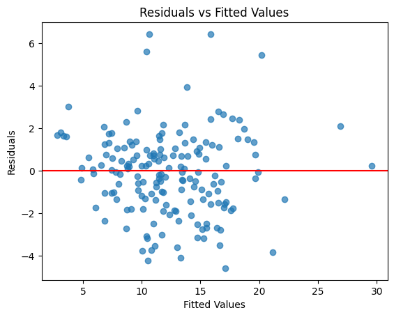

```python
# Residuals vs fitted values plot
residuals = y_test - y_pred
plt.scatter(y_pred, residuals, alpha=0.7)
plt.axhline(0, color='red')
plt.xlabel('Fitted Values')
plt.ylabel('Residuals')
plt.title('Residuals vs Fitted Values')
plt.show()
```

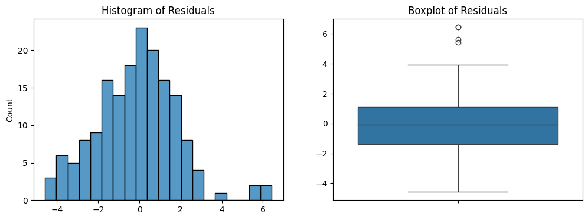

```python
fig, axes = plt.subplots(1, 2, figsize=(12,4))
# Histogram of residuals
sns.histplot(residuals, bins=20, edgecolor='black', ax=axes[0])
axes[0].set_title('Histogram of Residuals')
# Boxplot of residuals
sns.boxplot(residuals, ax=axes[1])
axes[1].set_title('Boxplot of Residuals')

plt.show()
```

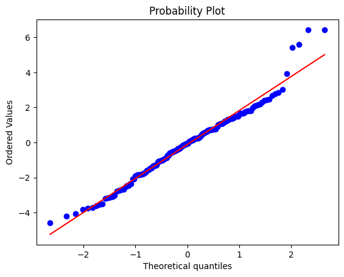

```python
# Q-Q plot to check for normality of residuals
stats.probplot(residuals, dist='norm', plot=plt)
plt.show()
```

**Key findings:**

- Residual vs. fitted plot shows more uniform spread.
- Residual distribution is symmetrical with few outliers.

## Model 3 with Transformed Dependent Variable, Interaction Term and Robust Standard Error

**Justification:** Using robust standard errors (HC3) corrects for heteroscedasticity and ensures valid inference, especially for the t-tests and p-values on coefficients.

```python
df3 = df.copy()
```

```python
# Apply transformation
df3['sqrt_poverty_rate'] = np.sqrt(df3['poverty_rate'])
```

```python
# Create interaction term
df3['income_x_house_value'] = (df3['log_median_income'] * df3['sqrt_median_house_value'])
```

**Build model 3:**

```python
predictors = df3.drop(columns=['sqrt_poverty_rate', 'poverty_rate'])
# Apply scaling
scaler = MinMaxScaler()
scaled_predictors = scaler.fit_transform(predictors)
scaled_predictors = pd.DataFrame(scaled_predictors, columns=predictors.columns)
scaled_predictors.head()
```

|  | health_insurance | unemployment_rate | bachelor_holders | public_assistance | log_median_income | log_public_transit | sqrt_median_house_value | income_x_house_value |
| --- | --- | --- | --- | --- | --- | --- | --- | --- |
| 0 | 0.809353 | 0.131579 | 0.431118 | 0.054976 | 0.407074 | 0.000000 | 0.324462 | 0.310475 |
| 1 | 0.733813 | 0.429825 | 0.165257 | 0.156398 | 0.160677 | 0.000000 | 0.171533 | 0.157415 |
| 2 | 0.672662 | 0.289474 | 0.132326 | 0.127014 | 0.261968 | 0.065926 | 0.222065 | 0.208068 |
| 3 | 0.553957 | 0.289474 | 0.089426 | 0.252133 | 0.055432 | 0.000000 | 0.166390 | 0.147781 |
| 4 | 0.780576 | 0.192982 | 0.343202 | 0.016114 | 0.402980 | 0.000000 | 0.249876 | 0.241420 |

```python
# Add intercept to scaled explanatory data and specify the dependent variable
X = sm.add_constant(scaled_predictors)
y = df3['sqrt_poverty_rate']

# Split data into training and testing sets
X_train, X_test, y_train, y_test = train_test_split(X, y, test_size=0.2, random_state=42)

# Fit the model
ols = sm.OLS(y_train, X_train)
model3 = ols.fit(cov_type='HC3')
```

**Validate model 3:**

```python
# Make predictions on the test set
y_pred = model3.predict(X_test)

# Calculate R-squared and MSE
r2 = r2_score(y_test, y_pred)
mse = mean_squared_error(y_test, y_pred)
print(f'R-squared: {r2}')
print(f'Mean Squared Error: {mse}')
```

```
R-squared: 0.8310581036269752
Mean Squared Error: 0.07192225315999508
```

```python
# View model summary
print(model3.summary())
```

```
                            OLS Regression Results
==============================================================================
Dep. Variable:      sqrt_poverty_rate   R-squared:                       0.796
Model:                            OLS   Adj. R-squared:                  0.793
Method:                 Least Squares   F-statistic:                     312.2
Date:                Tue, 22 Apr 2025   Prob (F-statistic):          2.10e-219
Time:                        23:16:10   Log-Likelihood:                -139.94
No. Observations:                 674   AIC:                             297.9
Df Residuals:                     665   BIC:                             338.5
Df Model:                           8
Covariance Type:                  HC3
===========================================================================================
                              coef    std err          z      P>|z|      [0.025      0.975]
-------------------------------------------------------------------------------------------
const                       5.0828      0.125     40.570      0.000       4.837       5.328
health_insurance           -0.3674      0.107     -3.445      0.001      -0.576      -0.158
unemployment_rate           0.8111      0.109      7.411      0.000       0.597       1.026
bachelor_holders            0.1332      0.116      1.149      0.251      -0.094       0.360
public_assistance           0.0735      0.120      0.613      0.540      -0.162       0.309
log_median_income          -5.2078      0.252    -20.651      0.000      -5.702      -4.713
log_public_transit          0.7545      0.095      7.940      0.000       0.568       0.941
sqrt_median_house_value   -18.3796      3.244     -5.666      0.000     -24.738     -12.021
income_x_house_value       20.4523      3.399      6.018      0.000      13.791      27.113
==============================================================================
Omnibus:                       16.933   Durbin-Watson:                   1.854
Prob(Omnibus):                  0.000   Jarque-Bera (JB):               34.163
Skew:                          -0.042   Prob(JB):                     3.82e-08
Kurtosis:                       4.100   Cond. No.                         677.
==============================================================================

Notes:
[1] Standard Errors are heteroscedasticity robust (HC3)
```

**Key findings:**

- Highest R-squared (0.796) and adjusted R-squared (0.793) among all models.
- `bachelor_holders` and `public_assistance` (with high p-values) are still the 2 insignificant predictors in the model.
- `sqrt_median_house_value`, `log_median_income`, `unemployment_rate`, `log_public_transit` and `health_insurance` remain high-impact predictors.
- `income_x_house_value` is significant (p-value = 0). This suggests the effect of income on poverty varies by home value, and vice versa.
- The sign of `sqrt_median_house_value`'s coefficient flips due to the interaction term in the refined model.

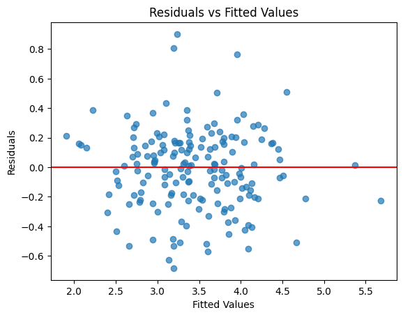

```python
# Residuals vs fitted values plot
residuals = y_test - y_pred
plt.scatter(y_pred, residuals, alpha=0.7)
plt.axhline(0, color='red')
plt.xlabel('Fitted Values')
plt.ylabel('Residuals')
plt.title('Residuals vs Fitted Values')
plt.show()
```

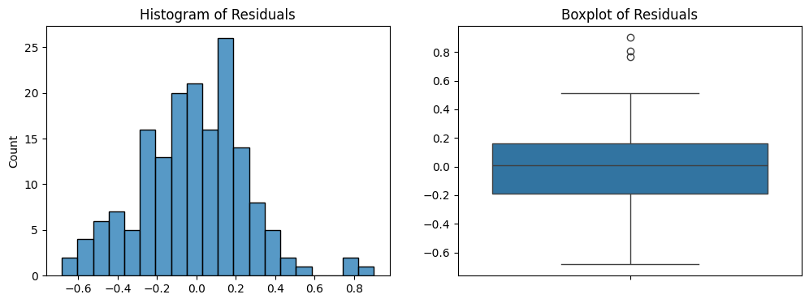

```python
fig, axes = plt.subplots(1, 2, figsize=(12,4))
# Histogram of residuals
sns.histplot(residuals, bins=20, edgecolor='black', ax=axes[0])
axes[0].set_title('Histogram of Residuals')
# Boxplot of residuals
sns.boxplot(residuals, ax=axes[1])
axes[1].set_title('Boxplot of Residuals')

plt.show()
```

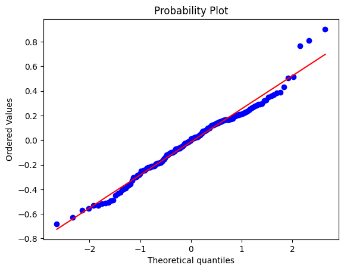

```python
# Q-Q plot to check for normality of residuals
stats.probplot(residuals, dist='norm', plot=plt)
plt.show()
```

**Key findings:**

- Robust standard errors reduce the impact of mild heteroscedasticity on inference.
- Normality and spread of residuals continue to look improved, with fewer extreme outliers compared to the baseline model.

## Conclusion

The model refinement process resulted in meaningful improvements over the initial baseline model.

- Transforming the dependent variable using a square root transformation helped address non-normality and stabilize variance.
- Introducing an interaction term between income and home value revealed that the combined effect of these factors is stronger than their individual impacts alone.
- Applying robust standard errors helped correct for mild heteroscedasticity and make the statistical results more reliable.

Overall, `model 3` explains more of the variances in poverty rates across counties and gives more trustworthy results.